# statistics

*solution_03_central_limit_theorem/02_normal/08_x_from_rightarea_v3*

[video (using z-table)](https://vimeo.com/531935144)

[video (using app)](https://vimeo.com/531935582): the [app](http://18.191.167.248:3838/nprob/)

First, draw a sketch. We can label the $B$ axis by adding integer multiples of 16 to 49. We know to shade the right because high values of $B$ satisfy the condition $B>b$ (regardless of the exact value of $b$). We don’t know exactly where to place the boundary, but we know the right area is 0.9.

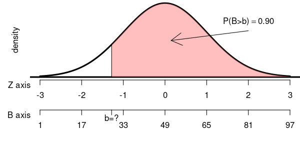

We know how to find the left area.
$$\begin{aligned}
P(B<b) &= 1-P(B>b) \\
&= 1-0.9 \\
&= 0.1
\end{aligned}$$

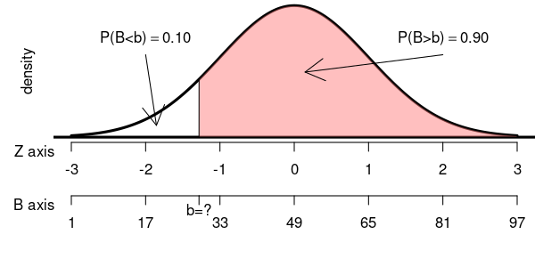

As an intermediate step, we find $z$ such that $P(Z<z)=0.1$.

By using the $z$ table we can determine $z$.

[output not shown]

Either -1.29 or -1.28 is a good estimation of $z$, and either value will lead you to an acceptable answer. Using other tools, a more accurate value can be found. I will show the work with a more accurate value.
$$z=-1.2816$$

We now convert the $z$ score into a $b$ score.
$$\begin{aligned}
b &= \mu+z\sigma \\
&= 49+(-1.2816)(16) \\
&= 28.5
\end{aligned}$$

We can also visualize this with a spinner.

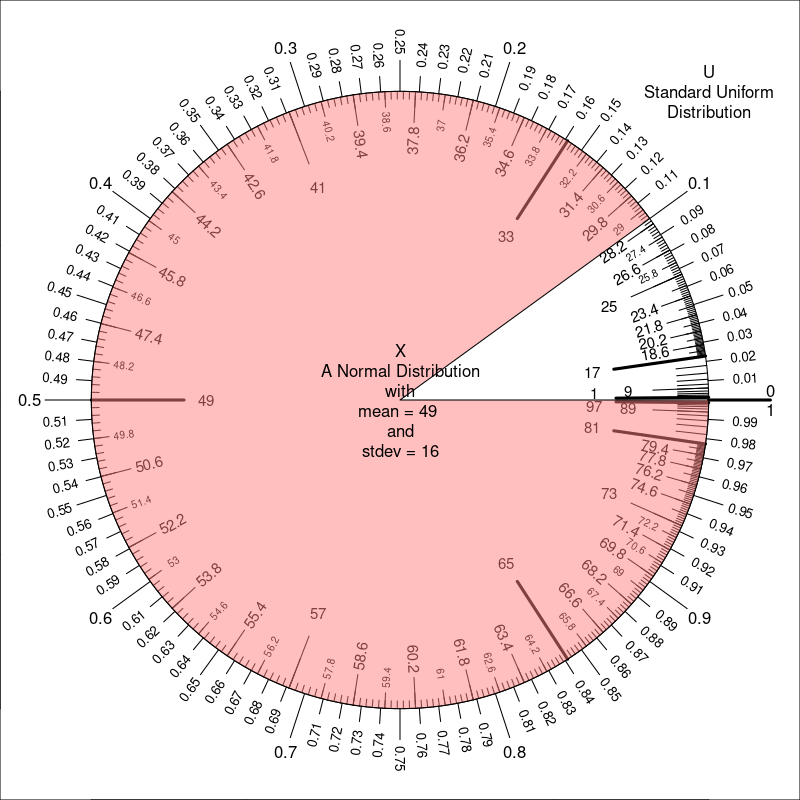

The tolerance for an acceptable answer was $\pm 1$ from 28.495175. So, anything between 27.495175 and 29.495175 was accepted.

ANSWERS: 28.495175  
TOLERANCES: 1